# Programy militarne USA

Wojciech Rosinski

14 listopada 2017

Źródło danych: [Wikipedia](https://en.wikipedia.org/wiki/Military_budget_of_the_United_States), inspirowane [reddit](https://www.reddit.com/r/dataisbeautiful/comments/7d01ug/military_spending_per_of_countries_annual_budget/).

## Dane

Stany Zjednoczone są jedną z potęg militarnych, wiodącą w rozwiązaniach innowacyjnych stosowanych w tej dziedzinie. Znalazłem dane, które przedstawiają wydatki na różnego rodzaju programy militarne w 2011 roku. Na podstawie nazw określiłem, czy jest to sprzęt do użytku lądowego, powietrznego, czy wodnego. Dodatkowo stworzyłem grupę, która zawiera w sobie programy modernizacyjne lub wymiany, a nie jest związana z rozwojem technologii mogącej służyć w określonym środowisku.

Aby móc stwierdzić, na jakiego rodzaju technologie przeznaczne zostały największe kwoty, pogrupowałem dane po środowisku, w którym technologia może zostać wykorzystana.

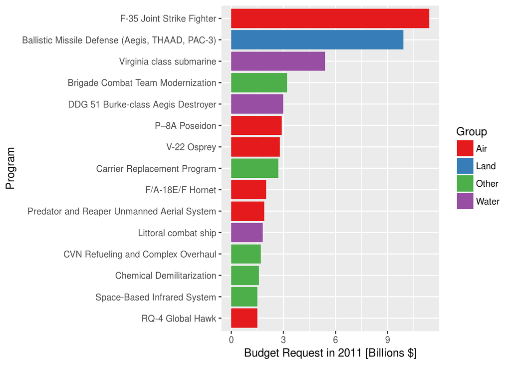

```r
g
```

## Wnioski

Dwa programy były szczególnie kosztowne - był to rozwój myśliwców F-35 oraz systemów obrony rakietowej Aegis, THAAD oraz PAC-3. Każdy z nich był około dwukrotnie droższy od programu rozwoju łodzi podwodnych klasy Virginia, który znalazł się na 3. miejscu. Najwięcej inwestycji zostało dokonanych w obszarze rozwiązań powietrznych, zaś tylko jedna inwestycja dotyczyła rozwiązań lądowych, były to właśnie systemy obrony rakietowej.

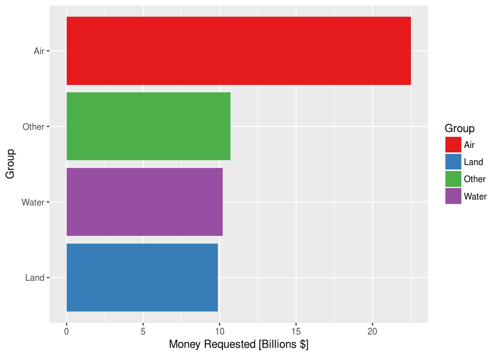

```r
g2
```

Wysokość budżetu przeznaczonego na inwestycje powietrzne przekracza ponad dwukrotnie każdą z kolejnych grup, wynosząc 22.5 mld dolarów. Na inne grupy przeznaczonych zostało około 10 mld dolarów. Widzimy więc, że USA zdecydowało się postawić na rozwój technologii powietrznych.